# Topic 21

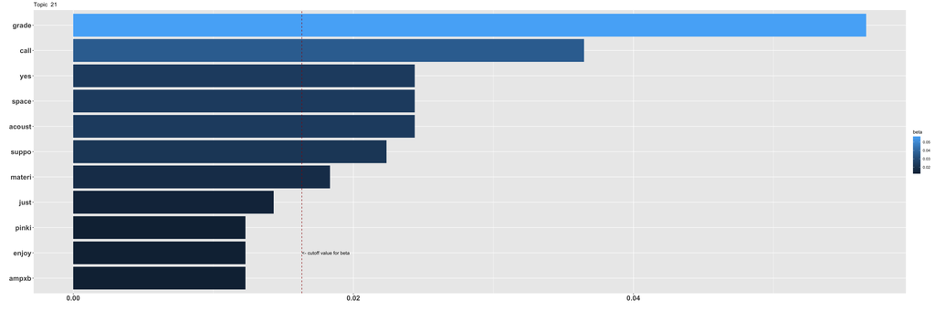

On interpreting beta: the term has a beta probability of being generated from the particular topic.

Values below are gamma : An estimated proportion of words from that document that are generated from that topic.

**Text Record Number: 1044** gamma: 13 % likelihood of this document (based on its words) in this topic

**I would say no, myself, for the following reasons: that key signature (C# minor) is not something you would natural come across until Grade 3 Theory, and Grade 4/5 Practical. 4-note chords are also not something that comes up until about Grade 4. Also, there’s very little to no octave chords in the left hand before Grade 4/5 either. Plus, it’s got a MM of crotchet equals 107…. quite fast to be finding those 4-note chords in the right hand. You can see where I’m going with this.

By all means try it, but if you are just about to start Grade 1, this piece is a good two years ahead of you.

Just do what I do - print it off, put it in a music folder labelled “Music I’m going to play in X years time”…. that way you can make a promise to yourself to do the ground work in the meantime, get the basics down etc, so when you do get to this piece in the future, you can do it proper justice and feel satisfied. As Guinness used to say on their TV adverts, “good things come to those who wait”.**

**Text Record Number: 639** gamma: 13 % likelihood of this document (based on its words) in this topic

**I’d say around grade 4/grade 5 level. Most of his Op 36 sonatinas are between grade 4 and grade 6 in AMEB/ABRSM**

**Text Record Number: 491** gamma: 13 % likelihood of this document (based on its words) in this topic

**That’s normal starting out. People often give you acronyms like “Every Good Boy Does Fine” (treble clef lines), “All Cows Eat Grass” (bass clef spaces), or “FACE” (treble clef spaces) for stuff like that. I promise you’ll get a lot better as you go.

https://www.youtube.com/watch?v=jSOU-J9KHbg

This video is also VERY helpful**

**Text Record Number: 627** gamma: 13 % likelihood of this document (based on its words) in this topic

**I too would say around G4. Although bear in mind that other movements of the same work featuring in other grades doesn’t necessarily mean the whole work would be of that grade.**

**Text Record Number: 347** gamma: 13 % likelihood of this document (based on its words) in this topic

**I suffer from this as well. It started to result in mild forearm strain after a while. My teacher (I just started learning with a teacher after 18 months self learning) gave me some VERY SIMPLE exercises to play, focusing on keeping fingertips on keys. Playing slow, posture and breathing help.**

**Text Record Number: 541** gamma: 13 % likelihood of this document (based on its words) in this topic

**Check out some of the [ABRSM Grade 1 pieces](https://gb.abrsm.org/en/our-exams/piano-exams/piano-grade-1/). You could also check out previous syllabuses for other ideas. Top tip: some of them will be available in the public domain for free on IMSLP if the composer died 70-100 years ago or later. [Trinity Grade 1 pieces](https://www.trinitycollege.com/qualifications/music/grade-exams/piano) might also be good!

For other compilation books, I teach using Pam Wedgewood’s Up-grade series. Grades 0-1 would be a good starting point there! Indeed, a lot of the stuff in her It’s Never Too Late to Play the Piano might be good too. Some will be too straightforward for you, as it assumes you are a beginner at the very start of the book, but it is a “learning” book so will cover a lot of the theory and stuff too (unlike Up-Grade).**

**Text Record Number: 710** gamma: 13 % likelihood of this document (based on its words) in this topic

**Thank you for the detailed response!

Yes I do agree the FP30X is a considerably good digital piano that replicates an acoustic one as far as it goes. I am happy with my purchase though it cost me $$$ haha. Noted on the need to warm up :> I do agree it’s important!

It’s just a little strange that for some reason, when I play the Kawai upright piano at the studio I take my classes, the music just sounds extremely loud even though I’m really not exerting too much strength (esp since I’m just a petite girl). Couldn’t wrap my head around this. If I could go softer, some notes would have been eaten up. Perhaps I could ask if it’s possible for me to stay back and uncover more about the piano so my future classes can be more effective…

Oh yes, I suppose I have to work more on reading the sheet music while also retaining that muscle memory. Feels like I’m too inclined on the latter now. :(**